# spaCraft: Analysis-aware power calculation and sample size planning for multi-sample spatial transcriptomics

## Defining the simulation gene sets

`makeCustomGeneSets()` turns the two selected sets into the three gene sets the simulator and the endpoints consume, for a chosen Target/Reference domain pair (here white matter vs. layer 6):

- `G_svg` — spatially variable genes (the markers plus stable genes) used to *label* spots;
- `G_null` — the stable / empirical-null genes; and
- `G_spike` — the top differentially expressed genes between Target and Reference, used for *signal injection*.

```r
library(spaCraft)
load("/Users/shin.991/Library/CloudStorage/Dropbox/postdoc/research/main_project/spaCraft/spaCraft_package/data/visium_human_brain_parameter_est_obj.RData")
load("/Users/shin.991/Library/CloudStorage/Dropbox/postdoc/research/main_project/spaCraft/spaCraft_package/data/visium_human_brain_lambda_tuning_obj.RData")
spaCraft_obj <- spaDesign2_obj

G_svg_base <- spaCraft_obj@params_expression$top_genes
G_stable   <- spaCraft_obj@params_expression$stable_genes

sets <- makeCustomGeneSets(
  object        = spaCraft_obj,
  G_svg_base    = G_svg_base,
  G_stable      = G_stable,
  target_domain = "WM",
  reference_domain    = "Layer6",
  sample_index  = 1L,
  n_de          = 5
)

lengths(sets[c("G_svg", "G_null", "G_spike")])
```

```
#>   G_svg  G_null G_spike
#>      31      20       5
```

```r
#head(sets$TR_stats, n=3)
```

## Fitting the three-layer generative model

With gene sets in hand we fit the cohort-level model. The three layers are independent calls and each writes into its own slot of `spaCraft_obj`.

**Expression (NNGP).** `estimateExpressionParams_v2()` estimates per-gene spatial covariance and biological variance across samples using nearest-neighbour Gaussian-process approximations (Saha & Datta, 2018), accelerated with Rcpp.

```r
spaCraft_obj <- estimateExpressionParams_v2(
  object           = spaCraft_obj,
  target_domain    = "WM",
  reference_domain = "Layer6",
  genes_to_use     = sets$G_svg,
  n_neighbors      = 15,
  n_cores          = 1,
  verbose          = TRUE
)
```

**Geometry (FGKMM).** `estimateGeometryParams_v2()` pools each domain’s spot cloud across samples and fits a Fisher–Gaussian kernel mixture (Mukhopadhyay, Li & Dunson, 2020), selecting the number of kernels by BIC over `M_candidates`.

```r
spaCraft_obj <- estimateGeometryParams_v2(
  object       = spaCraft_obj,
  M_candidates = 3:6,
  iter_max     = 1000,
  tol          = 1e-2,
  n_cores      = 1,
  verbose      = TRUE
)
```

**Composition (Binomial–logit).** `estimateCompositionParams_v2()` fits the baseline-anchored model for the Target-vs-Reference abundance; the pilot baseline becomes the null center used by the LOR TREAT test.

```r
spaCraft_obj <- estimateCompositionParams_v2(
  object           = spaCraft_obj,
  target_domain    = "WM",
  reference_domain = "Layer6",
  verbose          = TRUE
)
```

```r
names(spaCraft_obj@params_composition)   # baseline-anchored Binomial-logit
names(spaCraft_obj@params_expression)    # gene sets + NNGP parameters
names(spaCraft_obj@params_geometry)      # FGKMM geometry
```

We can visualize the pilot domains directly from the object. The S4 `plot()` method draws spatial domains with a consistent palette across samples:

```r
plot(spaCraft_obj, type = "pilot", n_per_group = 2)
```

[output not shown]

## (Optional) Stability-driven hyperparameter tuning

The recover step has two spatial knobs: the conditional-texture strength of the simulator (`lambda_cond`) and the BANKSY spatial-mixing weight of the clusterer (`lambda_p`). `tuneSpaDesignLambdas()` selects them by stability under a single scenario, returning endpoint-specific optima for SaLFC and LOR. This is a Monte-Carlo search, so it is shown here with small settings but **not run during the build** (set `eval = TRUE` to run it).

```r
tuning_H1_scenario <- list(
  DE_lfc = 0.3, target_prop_case = 0.7, kappa_geo = 1.0,
  kappa_m = 1.0, kappa_bio = 1.0, delta_rho = 1.0
)

tuning_obj <- tuneSpaDesignLambdas(
  object        = spaCraft_obj,
  target_domain = "WM", reference_domain = "Layer6",
  G_DE          = sets$G_spike,
  scenario_H1   = tuning_H1_scenario,
  lambda_p_grid = seq(0.3, 0.7, by = 0.1),   # small grid for speed
  lambda_c_grid = seq(0.3, 0.7, by = 0.1),
  B = 20, K_syn = 10, n_cores = 1, seed = 123
)

summary(tuning_obj)
plot(tuning_obj)
```

## Simulating a synthetic cohort

```r
class(spaCraft_obj) <- "spaCraft"

scenario_params <- list(
  DE_lfc           = 0.3,   # expression log-fold-change for DE genes
  target_prop_case = NULL,   # case-group target-domain proportion
  kappa_geo = 1.0, kappa_m = 1.0, kappa_bio = 1.1,
  delta_rho = 1.0, lambda_cond = tuning_obj$optimal_params$SaLFC$lambda_cond
)

sim_results <- simulatespaCraft(
  object             = spaCraft_obj,
  n_sample_per_group = 5,
  scenario_settings  = scenario_params,
  target_domain      = "WM",
  genes_to_simulate  = sets$G_svg,
  de_genes           = sets$G_spike,
  spatial_mode       = "original",
  graph_k            = 30L,
  n_cores            = 1
)
```

## Recovering spatial domains and visualizing

`pBANSKY()` recovers domain labels on the synthetic samples using a pilot-centroid-guided BANKSY embedding; the recovered labels are written to `coords$hat_d`. We then re-shape the synthetic blobs onto the pilot geometry with `rearrangeSyntheticToPilot()` and store the result back in the object.

```r
syn_d_hat <- pBANSKY(
  sim_data   = sim_results,
  pilot_data = spaCraft_obj@pilot_data,
  lambda = tuning_obj$optimal_params$SaLFC$lambda_p, k_neighbors = 30,
  scale_pilot_coords = FALSE, scale_sim_coords = FALSE,
  hard_guidance = FALSE, n_pcs = 20, do_hungarian = TRUE,
  use_G = TRUE, balance_mode = "energy_proportional"
)
```

[output not shown]

```r
# pack into the {counts, coords, meta} shape the downstream steps expect
synthetic_data <- setNames(
  lapply(syn_d_hat, function(item) {
    list(counts = item$counts, coords = item$coords,
         meta = data.frame(sample_id = item$sample_id, group = item$group))
  }),
  vapply(syn_d_hat, function(item) item$sample_id, character(1))
)

mapped_synthetic_data <- rearrangeSyntheticToPilot(
  synthetic_data   = synthetic_data,
  pilot_data       = spaCraft_obj@pilot_data,
  boundary_shift   = TRUE,          # render a composition shift as a moving boundary
  target_domain    = "WM",
  reference_domain = "Layer6"
)

syntheticData(spaCraft_obj) <- mapped_synthetic_data
```

**`lambda` and `boundary_shift`.** `lambda` is BANKSY’s spatial-mixing weight (0 = expression only, 1 = neighbourhood only); this is the `lambda_p` you would tune. `boundary_shift = TRUE` is appropriate for the LOR (composition) endpoint: it renders a larger case-group target proportion as the target band expanding into the reference, leaving per-domain counts (and hence the LOR statistic) untouched while only the spatial footprint changes.

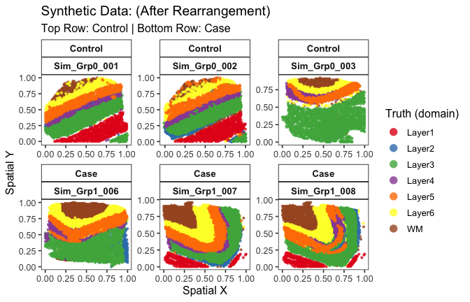

```r
plot(spaCraft_obj, type = "synthetic_mapped",
     color_by = "domain", n_per_group = 3, cex = 1.2, alpha = 0.8)
```

## A single-design-point test

Before sweeping a grid, it is instructive to apply each endpoint **once** to the single synthetic cohort we just recovered. This exposes the raw test output and is exactly the computation that `evaluatePowerSaLFC()` and `evaluatePowerLOR()` repeat internally at every cell. We pass `synthetic_data` — the recovered cohort carrying cluster labels in `coords$hat_d` — and let both tests derive their TREAT thresholds directly from the pilot (`lfc_threshold = "pilot"`, `tau = "pilot"`).

```r
res_SaLFC <- SaLFC(
  synthetic_data, spaCraft_obj,
  genes         = sets$G_null,
  target_domain = "WM", reference_domain = "Layer6",
  domain_col    = "hat_d",
  lfc_threshold = "pilot"
)

sets$G_null               # empirical-null genes
sets$G_spike              # injected-DE genes (relevant when DE_lfc > 0)
round(res_SaLFC$p_value, 5)
```

[output not shown]

```r
res_LOR <- LOR(
  synthetic_data, spaCraft_obj,
  target_domain = "WM", reference_domain = "Layer6",
  null_type = "treat", tau = "pilot"
)

res_LOR$p_value
```

[output not shown]

Each rejection (`p_value <= alpha`) is a single Bernoulli outcome; the power functions below simply average many such outcomes across the grid.

## Power analysis

### SaLFC — spatially adjusted differential expression

The swept effect is the expression log-fold-change `lfc_grid`. Pilot-based TREAT thresholds are estimated once per effect size and shared across replicates.

```r
# Note: This evaluation is computationally intensive.
power_results <- evaluatePowerSaLFC(
  object   = spaCraft_obj,
  K_grid   = seq(3, 9, by=1),
  lfc_grid = c(0.30, 0.40, 0.50),
  n_sim    = 10,
  seed     = 2026,
  G_svg    = sets$G_svg,
  G_null   = sets$G_null,
  G_spike  = sets$G_spike,
  scenario_base   = list(lambda_cond = tuning_obj$optimal_params$SaLFC$lambda_cond),
  clustering_args = list(lambda = tuning_obj$optimal_params$SaLFC$lambda_p)
)
```

```r
library(dplyr); library(ggplot2); library(ggrepel); library(scam)
library(spaCraft)
# Load pre-computed power results from the package to expedite vignette rendering
salfc_csv_url <- "/Users/shin.991/Library/CloudStorage/Dropbox/postdoc/research/main_project/spaCraft/spaCraft_package/data/Visium_human_brain_power_results_SaLFC.csv"
power_results <- read.csv(salfc_csv_url)

print(head(power_results))
```

```
#>   K_syn DE_lfc adjust_method test_method eval_domain_col rearrange strict_ok
#> 1     3   0.25    bonferroni           t           hat_d      TRUE      TRUE
#> 2     3   0.25    bonferroni           t           hat_d      TRUE      TRUE
#> 3     3   0.25    bonferroni           t           hat_d      TRUE      TRUE
#> 4     3   0.25    bonferroni           t           hat_d      TRUE      TRUE
#> 5     3   0.25    bonferroni           t           hat_d      TRUE      TRUE
#> 6     3   0.25    bonferroni           t           hat_d      TRUE      TRUE
#>   power_strict power_raw fdp n_rej n_TP n_FP n_test n_DE spatial_mode rep
#> 1          0.0       0.0   0     0    0    0     10    5     original   1
#> 2          0.0       0.0   0     0    0    0     10    5     original   2
#> 3          0.0       0.0   0     0    0    0     10    5     original   3
#> 4          0.0       0.0   0     0    0    0     10    5     original   4
#> 5          0.2       0.2   0     1    1    0     10    5     original   5
#> 6          0.0       0.0   0     0    0    0     10    5     original   6
#>   seed_used
#> 1     10201
#> 2     10202
#> 3     10203
#> 4     10204
#> 5     10205
#> 6     10206
```

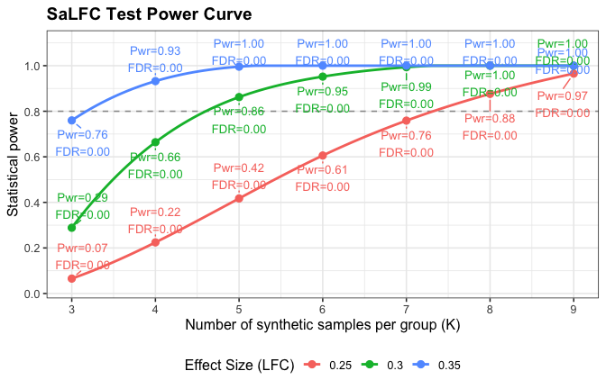

```r
plotPowerCurveSaLFC(power_results, alpha = 0.05)
```

### LOR — compositional shift

Here the swept effect is the case-group target proportion (`effect_type = "target_prop_case"`); expression DE is switched off internally so the signal is purely compositional. LOR returns a single test per replicate, so power is simply the rejection rate.

```r
# Note: This evaluation is computationally intensive.
lor_results <- evaluatePowerLOR(
  object      = spaCraft_obj,
  K_grid      = seq(3, 9, by=1),
  delta_grid  = c(0.60, 0.70, 0.80),
  effect_type = "target_prop_case",
  n_sim       = 10,
  seed        = 2026,
  genes       = sets$G_svg,
  scenario_base   = list(lambda_cond = tuning_obj$optimal_params$LOR$lambda_cond),
  clustering_args = list(lambda = tuning_obj$optimal_params$LOR$lambda_p)
)
```

```r
library(dplyr); library(ggplot2); library(ggrepel); library(scam)
library(spaCraft)
lor_csv_url <- "/Users/shin.991/Library/CloudStorage/Dropbox/postdoc/research/main_project/spaCraft/spaCraft_package/data/Visium_human_brain_power_results_LOR.csv"
lor_results <- read.csv(lor_csv_url)

print(head(lor_results))
```

```
#>   K_syn effect      effect_type delta_pp target_prop_case null_type eval_on
#> 1     3    0.5 target_prop_case       NA              0.5     treat   hat_d
#> 2     3    0.5 target_prop_case       NA              0.5     treat   hat_d
#> 3     3    0.5 target_prop_case       NA              0.5     treat   hat_d
#> 4     3    0.5 target_prop_case       NA              0.5     treat   hat_d
#> 5     3    0.5 target_prop_case       NA              0.5     treat   hat_d
#> 6     3    0.5 target_prop_case       NA              0.5     treat   hat_d
#>   test_method reject   p_value delta_hat    delta0 delta_tilde       tau K0 K1
#> 1           t  FALSE 0.3650292 0.4307171 0.1927264   0.2379907 0.1350878  3  3
#> 2           t  FALSE 0.3510681 0.4520862 0.1927264   0.2593598 0.1350878  3  3
#> 3           t  FALSE 0.4646511 0.3541249 0.1927264   0.1613985 0.1350878  3  3
#> 4           t   TRUE 0.0102806 0.8093831 0.1927264   0.6166567 0.1350878  3  3
#> 5           t  FALSE 0.2302085 0.5244662 0.1927264   0.3317398 0.1350878  3  3
#> 6           t  FALSE 0.2062331 0.5407977 0.1927264   0.3480713 0.1350878  3  3
#>   rep seed_used
#> 1   1     10201
#> 2   2     10202
#> 3   3     10203
#> 4   4     10204
#> 5   5     10205
#> 6   6     10206
```

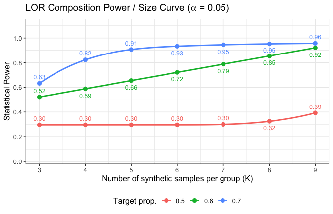

```r
plotPowerCurveLOR(lor_results, alpha = 0.05)
```